# Ataxia cohort — mtDNA Variant Report

25 May 2026

# Coverage

**ℹ️ Coverage metrics**

**Median depth** — median per-base sequencing depth across the mitochondrial genome (chrM) after Mutect2 calling. Samples below the threshold (100x) are flagged.

**mtDNA copy number (mtDNA-CN)** — estimated number of mitochondrial genome copies per cell, calculated from the ratio of mitochondrial to nuclear read counts.

**CV (coefficient of variation)** — sd / mean depth across all mtDNA positions. High CV (> 0.2) indicates uneven coverage, which can affect variant calling reliability.

**Cumulative coverage** — proportion of mtDNA bases covered at ≥ X depth. Useful for assessing whether low-depth regions will limit heteroplasmy detection.

## Depth per sample

[interactive chart not shown]

## mtDNA-CN

[interactive chart not shown]

## Base coverage

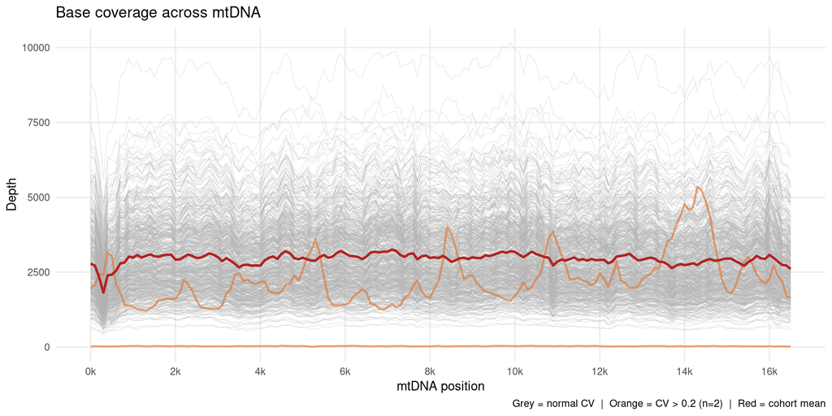

## Cumulative coverage

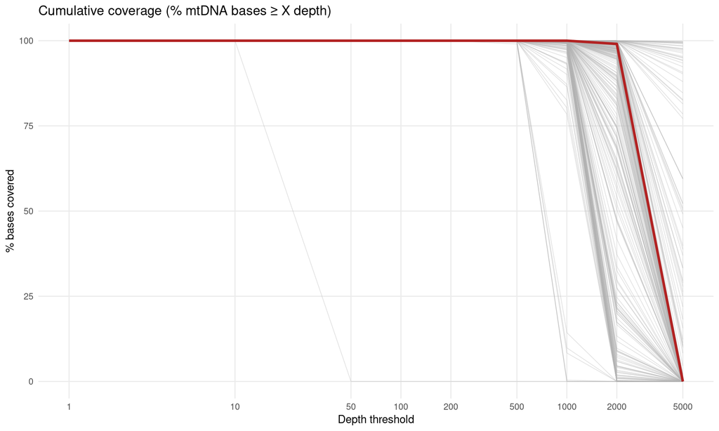

## CV distribution

[interactive chart not shown]

# Contamination

**ℹ️ Contamination (haplocheck)**

## Level per sample

[interactive chart not shown]

## Level vs depth

[interactive chart not shown]

# Haplogroup

**ℹ️ Haplogroup assignment**

Haplogroups are assigned by mitoHPC using the mtDNA phylogeny. **Macro-haplogroups** are the top-level branches (e.g. H, J, L0). Samples are grouped into three major **clades**: L (African), M (Asian/Oceanian), and N/R (Eurasian/American).

**Assignment quality** is a score (0–1) reflecting confidence in the haplogroup call. Scores below 0.5 (red line) indicate poor assignment; scores below 0.8 (orange line) may warrant manual review.

## Macro-haplogroup distribution

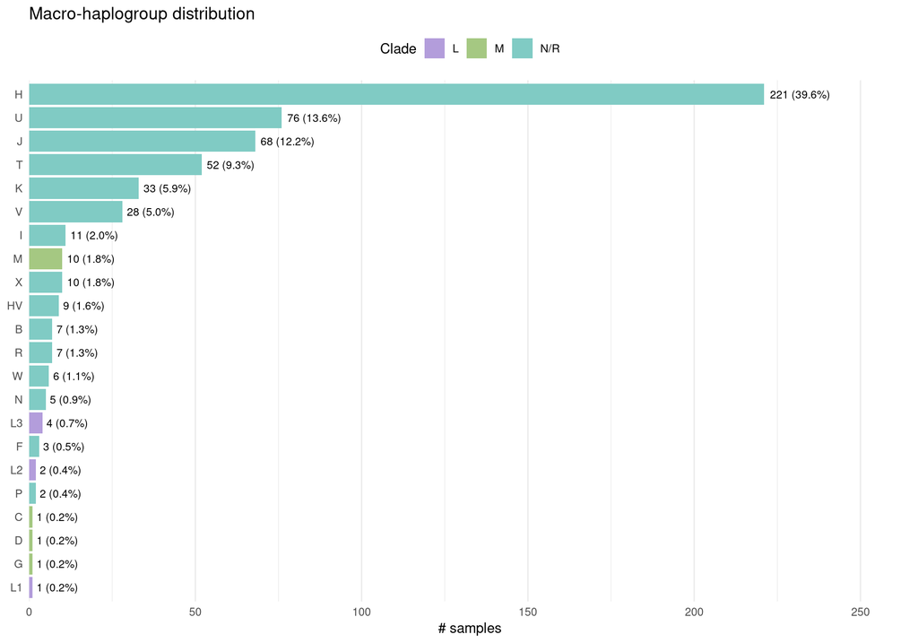

## Assignment quality

[interactive chart not shown]

# PCA

**ℹ️ mtDNA PCA projection**

Cohort samples are projected onto a pre-computed PCA space derived from 1000 Genomes Project (1000G) mtDNA data. The PCA uses 317 homoplasmic variant sites. Each cohort sample’s allele dosage vector is mean-centred and multiplied by the 1000G loadings matrix to produce PC scores.

Clustering of cohort samples with 1000G groups reflects ancestral haplogroup structure. Outliers may indicate unusual haplogroup composition, data quality issues, or nuclear mitochondrial DNA (NUMT) contamination.

## PC1 vs PC2

[interactive chart not shown]

## PC2 vs PC3

[interactive chart not shown]

## Scree plot

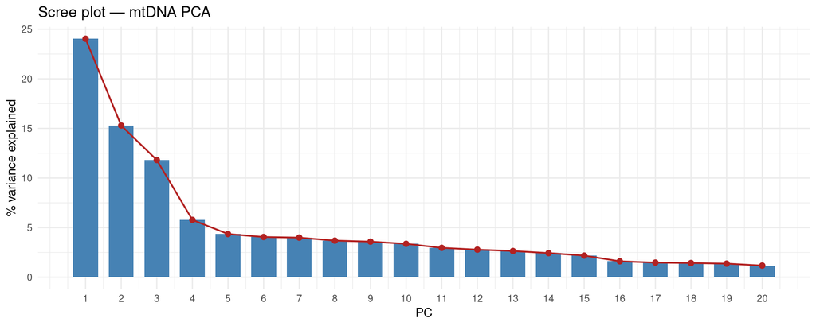

# Variants

**ℹ️ Variant calling and classification**

Variants are called by Mutect2 in mitochondrial mode. PASS variants with VAF ≥ 0.03 are retained after blacklist filtering and strand bias exclusion.

**Homoplasmic** — VAF ≥ 0.95 (variant present in nearly all mitochondrial copies). **Heteroplasmic** — 0.03 ≤ VAF < 0.95 (variant present in a subset of copies).

**MLC score** — Mitochondrial Local Constraint score (0–1). Higher scores indicate greater predicted functional impact based on local sequence constraint.

**Variant class** — a unique variant (POS:REF:ALT) is classified as *homoplasmic only*, *heteroplasmic only*, or *homoplasmic/heteroplasmic* based on whether it appears homoplasmic in at least one sample, heteroplasmic in at least one sample, or both.

**Frequency spectrum** — cohort allele frequency of each unique variant, binned from singletons to common variants (>10% of samples).

## Summary

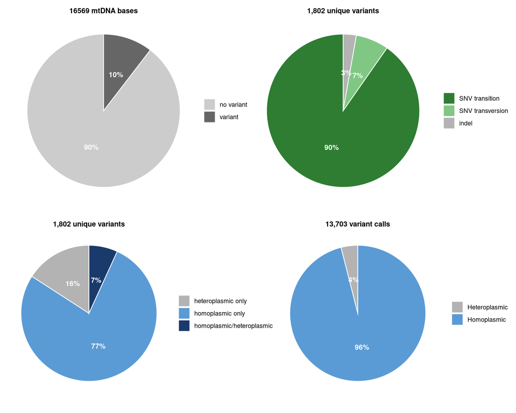

## VAF distribution

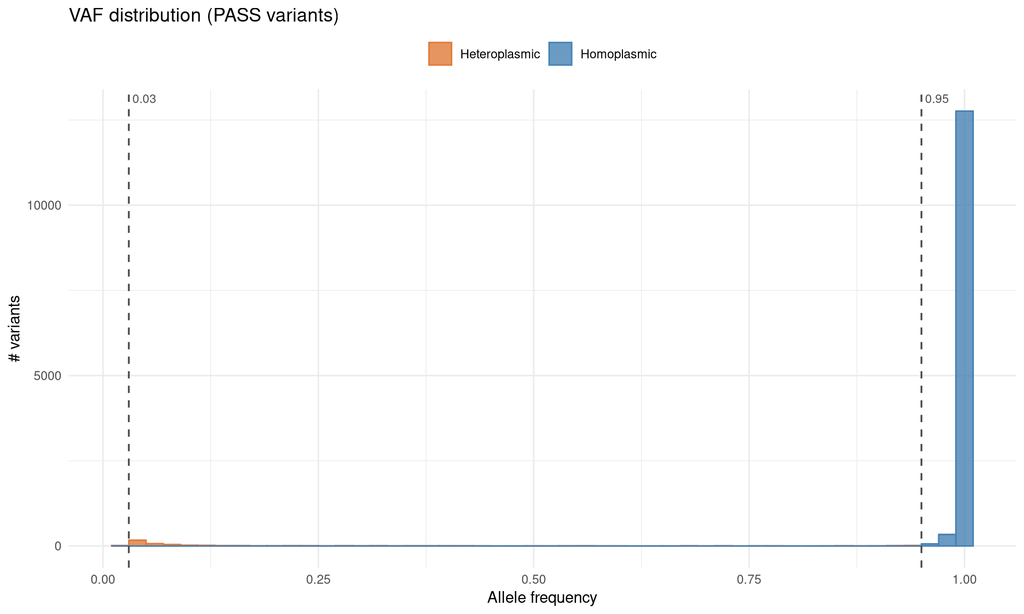

## Homoplasmy by clade

[interactive chart not shown]

## Heteroplasmy by clade

[interactive chart not shown]

## MSS

[interactive chart not shown]

## Consequence breakdown

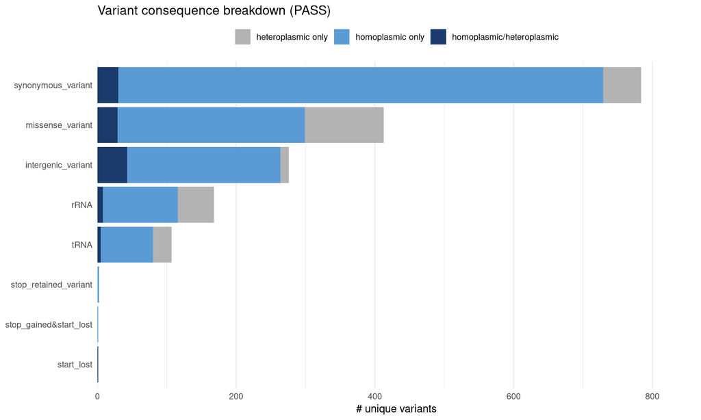

## MLC score

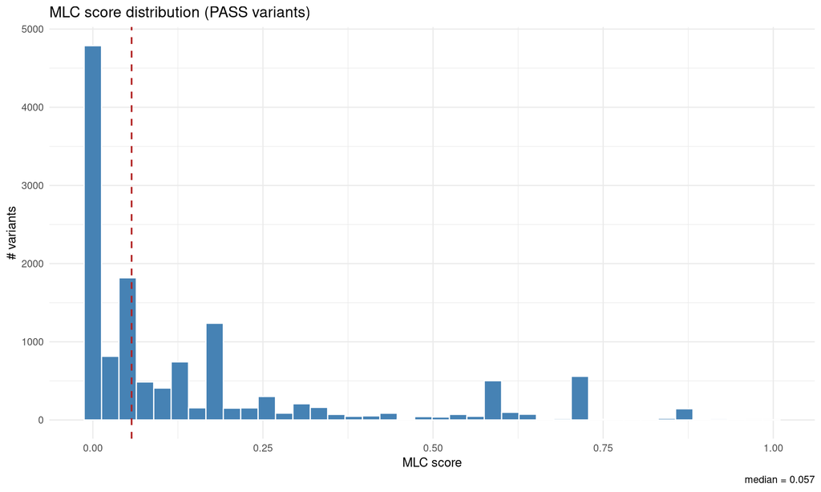

## Frequency spectrum

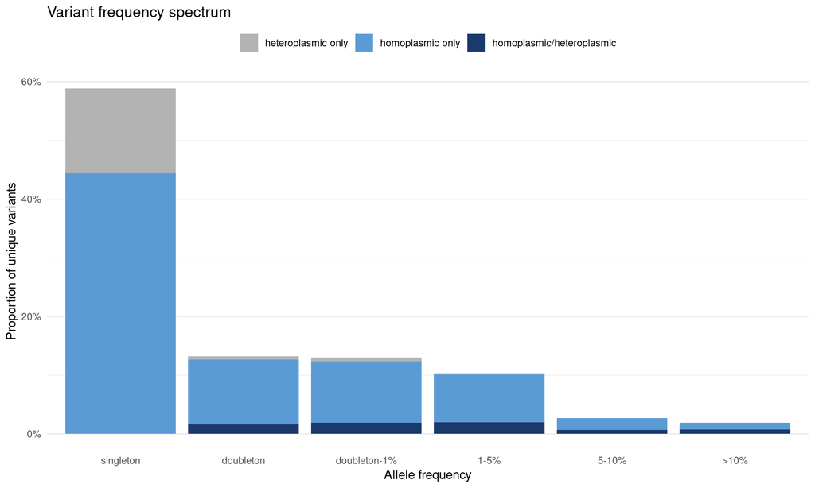

# Relatedness

**ℹ️ Relatedness / duplicate detection**

Pairwise **Jaccard similarity** is computed on the set of PASS homoplasmic variants (VAF ≥ 0.95) for each sample pair. Jaccard = |intersection| / |union| of variant key sets (POS:REF:ALT).

- **Jaccard = 1.0** — identical variant profiles; probable duplicate or sample swap.
- **Jaccard > 0.95** — near-identical profiles; probable mother-offspring or close relative.

Note: samples sharing the same haplogroup will have elevated Jaccard due to haplogroup-defining variants, but duplicates/relatives will be near 1.0 while unrelated same-haplogroup samples cluster well below this.

## Pairwise similarity

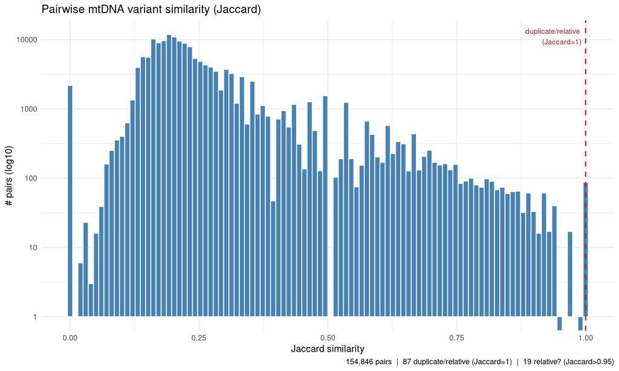

## Flagged pairs

[interactive chart not shown]

# QC Summary

## Flags

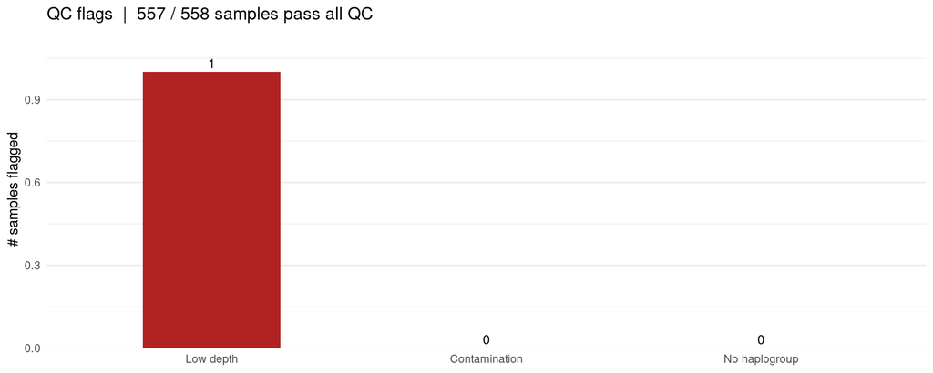

## Sample table

[output not shown]

[output cut: 548 more lines]

# Glossary

**VAF (variant allele frequency)** — proportion of mitochondrial DNA copies carrying the variant allele (0–1).

**CV (coefficient of variation)** — sd / mean depth; measure of coverage uniformity across the mtDNA genome.

**Haplogroup** — a clade of mitochondrial genomes defined by shared polymorphisms, reflecting maternal ancestry.

**Heteroplasmy** — co-existence of more than one mitochondrial DNA variant at a given position within a cell or tissue. Here defined as 0.03 ≤ VAF < 0.95.

**Homoplasmy** — a variant present in (nearly) all mitochondrial DNA copies. Here defined as VAF ≥ 0.95.

**Jaccard similarity** — |A ∩ B| / |A ∪ B| for two sets of variants; ranges 0 (no overlap) to 1 (identical).

**MLC score** — Mitochondrial Local Constraint score (0–1); higher = greater predicted functional impact based on local sequence constraint.

**MSS (Mitochondrial Local Constraint Score Sum)** — per-sample sum of MLC scores across all heteroplasmic PASS variants. Reflects the aggregate constraint burden of heteroplasmic variants in a sample.

**mtDNA-CN** — mitochondrial DNA copy number; estimated copies of the mitochondrial genome per cell.

**NUMT** — nuclear mitochondrial DNA segment; a mtDNA sequence integrated into the nuclear genome that can confound variant calling.

*Report generated: 2026-05-25 14:41 | Cohort: Ataxia cohort | Samples: 558 | R version: R version 4.5.3 (2026-03-11)*